# TCORS ASTHMA OVERLAP

Elise Hickman

2023-10-10

# Set up workspace

```r
# Clear global environment
rm(list=ls())

# Load packages
library(janitor) # for data cleaning
library(openxlsx) # for writing out files
library(tidyverse) # for data organization and manipulation
library(vegan) # for jaccard
library(cluster) # for clustering
library(factoextra) # for clustering
library(pheatmap)

# Set theme
theme_set(theme_bw())

# Set seed (if needed)
set.seed(8016)
```

# Import Data

First, we will read in data describing proteins that have significantly higher or lower expression in the sputum of e-cig users vs. controls (from Reidel et al 2017) or in different proteotypes of asthma (eosinophilic, neutrophilic, atopic) vs. controls (from Schofield et al 2019). Note that for e-cig users, these proteins were all significantly higher in the e-cig group, but for the asthmatic groups, some proteins were lower in asthmatics vs. controls.

```r
ecig <- read.xlsx("1_InputData/Ecig_vs_Control.xlsx")

eos <- read.xlsx("1_InputData/EosinophilicAsthma_vs_Control.xlsx") %>%
  filter(fdr_pval < 0.05)

neut <- read.xlsx("1_InputData/NeutrophilicAsthma_vs_Control.xlsx") %>%
  filter(fdr_pval < 0.05)

atop <- read.xlsx("1_InputData/AtopicAsthma_vs_Control.xlsx") %>%
  filter(fdr_pval < 0.05)
```

# Quantify Overlap By Counts

How many proteins overlap between the e-cig and asthma lists?

```r
overlap_ecig_eos <- ecig$protein[ecig$protein %in% eos$protein]
length(overlap_ecig_eos)
```

```
## [1] 9
```

```r
overlap_ecig_neut <- ecig$protein[ecig$protein %in% neut$protein]
length(overlap_ecig_neut)
```

```
## [1] 19
```

```r
overlap_ecig_atop <- ecig$protein[ecig$protein %in% atop$protein]
length(overlap_ecig_atop)
```

```
## [1] 1
```

How many proteins overlap between the e-cig and asthma lists when only the proteins that were higher in asthma vs. control are considered?

```r
# Filter data
ecig_higher <- ecig %>% filter(direction_vs_controls == "higher")
eos_higher <- eos %>% filter(direction_vs_controls == " higher")
neut_higher <- neut %>% filter(direction_vs_controls == " higher")
atop_higher <- atop %>% filter(direction_vs_controls == " higher")

# Quantify overlap
overlap_ecig_eos_higher <- ecig$protein[ecig_higher$protein %in% eos_higher$protein]
length(overlap_ecig_eos_higher)
```

```
## [1] 9
```

```r
overlap_ecig_neut_higher <- ecig$protein[ecig_higher$protein %in% neut_higher$protein]
length(overlap_ecig_neut_higher)
```

[output not shown]

```r
overlap_ecig_atop_higher <- ecig$protein[ecig_higher$protein %in% atop_higher$protein]
length(overlap_ecig_atop_higher)
```

```
## [1] 0
```

How many proteins overlap between the e-cig and asthma lists when only the proteins that were lower in asthma vs. control are considered?

```r
# Filter data
ecig_lower <- ecig %>% filter(direction_vs_controls == "lower")
eos_lower <- eos %>% filter(direction_vs_controls == " lower")
neut_lower <- neut %>% filter(direction_vs_controls == " lower")
atop_lower <- atop %>% filter(direction_vs_controls == " lower")

# Quantify overlap
overlap_ecig_eos_lower <- ecig$protein[ecig_lower$protein %in% eos_lower$protein]
length(overlap_ecig_eos_lower)
```

```
## [1] 0
```

```r
overlap_ecig_neut_lower <- ecig$protein[ecig_lower$protein %in% neut_lower$protein]
length(overlap_ecig_neut_lower)
```

```
## [1] 0
```

```r
overlap_ecig_atop_lower <- ecig$protein[ecig_lower$protein %in% atop_lower$protein]
length(overlap_ecig_atop_lower)
```

```
## [1] 0
```

How many proteins overlap between the e-cig and asthma lists when only the proteins that were higher in asthma vs. control are considered and when asthma subtypes are pooled together?

```r
# Extract unique proteins from the eosinophilic and neutrophilic lists (since there was no overlap with atopic)
unique_asthma_higher <- unique(c(eos_higher$protein, neut_higher$protein))

# Determine overlap between ecig and asthma
overlap_ecig_asthma_all <- ecig$protein[ecig$protein %in% unique_asthma_higher]
length(overlap_ecig_asthma_all)
```

```
## [1] 21
```

# Quantify Overlap by Jaccard + Heatmap for All Proteins

## Create Count Matrix

First, make a count matrix of presence/absence for proteins significantly increased in each group.

```r
# Make a list of unique genes that were higher across asthma proteotypes and e-cig users
all_proteins <- unique(c(eos_higher$protein, neut_higher$protein, ecig$protein, atop_higher$protein))

# Create count matrix based on presence/absence in each disease

## Add a column to each data frame where the column name is the group and 1 indicates presence in that data frame
ecig <- ecig %>% mutate(ecig = 1)
eos_higher <- eos_higher %>% mutate(eos_asthma = 1)
neut_higher <- neut_higher %>% mutate(neut_asthma = 1)
atop_higher <- atop_higher %>% mutate(atop_asthma = 1)

# Merge all of the count columns and replace NAs (absence of a protein in that list) with zero
protein_countmatrix <- data.frame(protein = all_proteins) %>%
  left_join(ecig %>% select(c(protein, ecig)), by = "protein") %>%
  left_join(eos_higher %>% select(c(protein, eos_asthma)), by = "protein") %>%
  left_join(neut_higher %>% select(c(protein, neut_asthma)), by = "protein") %>%
  left_join(atop_higher %>% select(c(protein, atop_asthma)), by = "protein") %>%
  replace(is.na(.), 0) %>%
  column_to_rownames("protein")
```

## Determine Jaccard Distance Between Groups

Jaccard distance between groups with all proteins included (not just those that are shared between e-cig and asthma):

```r
# Transpose dataframe and convert to matrix
protein_countmatrix_T <- as.data.frame(t(protein_countmatrix))

# Calculate Jaccard *distance* for groups
group_jaccard_dist <- vegdist(protein_countmatrix_T , method="jaccard", na.rm = TRUE)
group_jaccard_dist <- as.data.frame(as.matrix(group_jaccard_dist))

# Calculate Jaccard *similarity* (JD+JS=1  ->  JS=1-JD) for genes
group_jaccard_sim <- group_jaccard_dist %>% mutate(across(everything(),~1-.x))

# View Jaccard similarity
group_jaccard_sim
```

```
##                   ecig eos_asthma neut_asthma atop_asthma
## ecig        1.00000000 0.07826087  0.16239316  0.00000000
## eos_asthma  0.07826087 1.00000000  0.25000000  0.07500000
## neut_asthma 0.16239316 0.25000000  1.00000000  0.03773585
## atop_asthma 0.00000000 0.07500000  0.03773585  1.00000000
```

## Cluster Proteins By Jaccard Distance

Jaccard distance between genes and determining number of clusters:

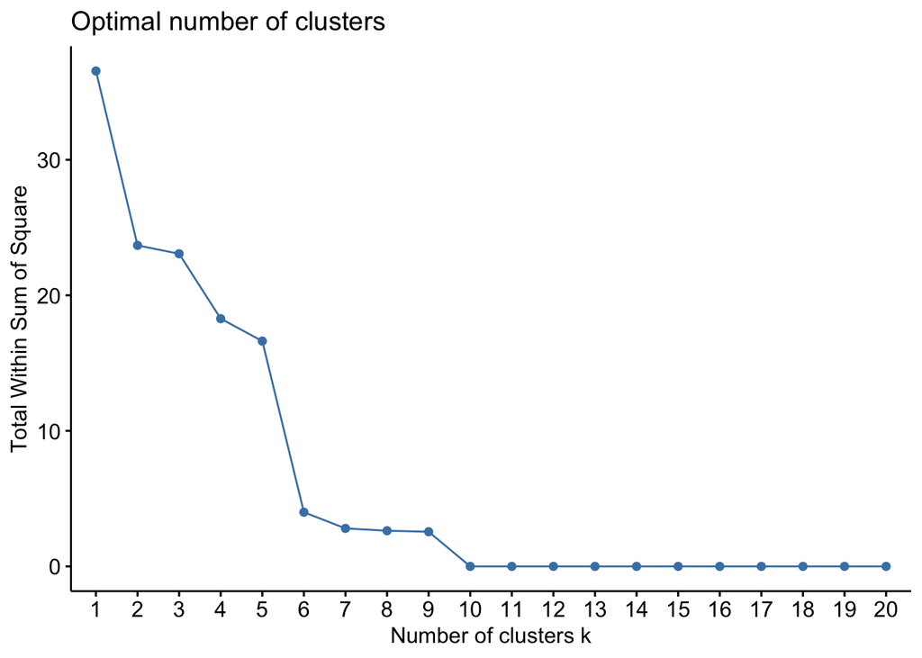

```r
# Calculate Jaccard *distance* for proteins
protein_jaccard_dist <- vegdist(protein_countmatrix, method="jaccard")
protein_jaccard_dist <- as.data.frame(as.matrix(protein_jaccard_dist))

# Cluster proteins
protein_cluster_samps <-diana(protein_jaccard_dist , diss=TRUE)

#use WSS and silhouette profile to identify the optimal number of clusters. This is subjective!! Generally look for "elbow point" in WSS and peak in silhouette profile. Could also look at "gap_stat" which is fairly common. Note, you will need to adjust your k.max to reflect the size of your data frame. It can't be >= the max number of rows you have.
fviz_nbclust(protein_countmatrix, diss = protein_jaccard_dist, method = "wss", FUN=hcut, hc_func="diana", k.max=20)
```

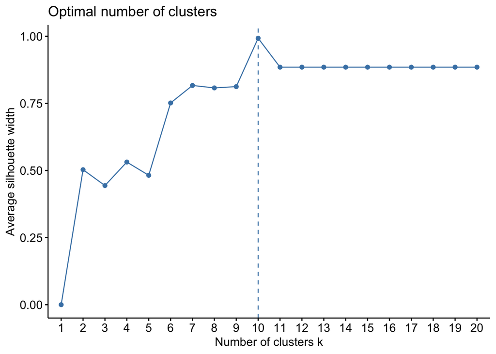

```r
fviz_nbclust(protein_countmatrix , diss = protein_jaccard_dist, method = "silhouette", FUN=hcut, hc_func="diana", k.max=20)
```

Based on these plots, we will proceed with 10 clusters of proteins.

```r
# Choose number of clusters
protein_cluster_assignments <- cutree(protein_cluster_samps, k = 10)

# Add in cluster labels to datafame and arrange by cluster number
protein_countmatrix$cluster <- protein_cluster_assignments
protein_countmatrix <- protein_countmatrix %>% arrange(cluster)
```

## Make a Heatmap

[figure not shown]

```r
# Set order for heatmap
cluster_order <- c(10, 1, 6, 5, 3, 8, 2, 7, 4, 9)

# Create a new data frame with modifications needed for heatmap
hm_data <- protein_countmatrix %>%
  relocate(neut_asthma, .before = eos_asthma) %>%
  rename("E-Cig" = "ecig", "Neut Asthma" = "neut_asthma", "Eos Asthma" = "eos_asthma", "Atopic Asthma" = "atop_asthma") %>%
  arrange(factor(cluster, levels = cluster_order))

# Add an index value into the dataframe so we can add splits between clusters in heatmap
hm_data$index <- 1:nrow(hm_data)

# Make lists of where breaks should be placed in the heatmap to separate clusters of samples
seprows <- hm_data %>% group_by(cluster) %>% slice_max(n=1, order_by=index)
seprows <- sort(seprows$index)

# Make heatmap
heatmap <- pheatmap(hm_data %>% select(-c(cluster, index)),
         cluster_rows = FALSE,
         cluster_cols = FALSE,
         show_rownames = FALSE,
         show_colnames = TRUE,
         color = c("gray91","orange1"),
         legend = FALSE,
         fontsize = 30,
         angle_col = 0,
         gaps_row = seprows,
         border_color = "black")

heatmap
```

```r
ggsave(heatmap, file = "2_OutputFigs/Ecig_Asthma_Overlap_Heatmap_All.png", width = 12, height = 20)
```

# Heatmap and Jaccard for Only Shared Proteins Between E-Cig and Asthma

Without annotation:

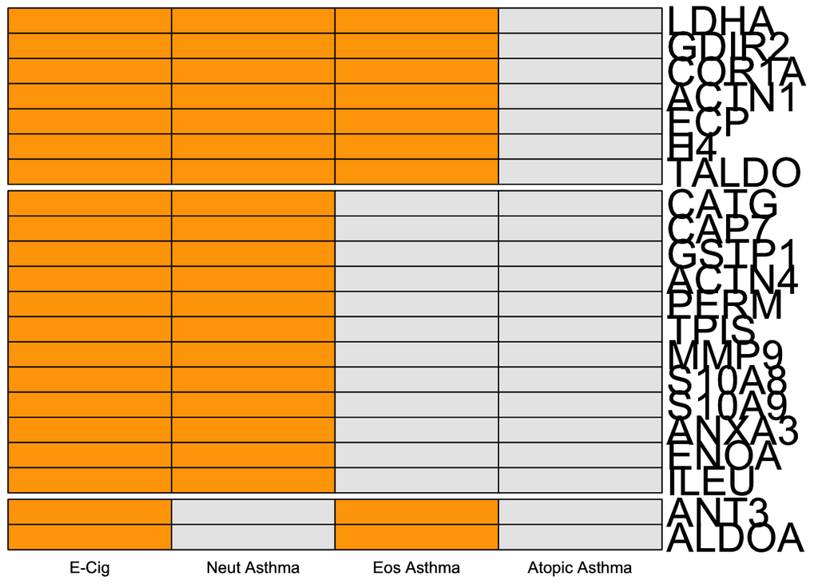

```r
# Subset data
protein_countmatrix_subset <- protein_countmatrix %>%
  filter(cluster == 2 | cluster == 7 | cluster == 4)

# Set order for heatmap
cluster_order <- c(2, 7, 4)

# Create new heatmap dataframe
hm_data_subset <- protein_countmatrix_subset %>%
  relocate(neut_asthma, .before = eos_asthma) %>%
  rename("E-Cig" = "ecig", "Neut Asthma" = "neut_asthma", "Eos Asthma" = "eos_asthma", "Atopic Asthma" = "atop_asthma") %>%
  arrange(factor(cluster, levels = cluster_order))

# Add an index value into the dataframe so we can add splits between clusters in heatmap
hm_data_subset$index <- 1:nrow(hm_data_subset)

# Make lists of where breaks should be placed in the heatmap to separate clusters of samples
seprows <- hm_data_subset %>% group_by(cluster) %>% slice_max(n=1, order_by=index)
seprows <- sort(seprows$index)

# Make heatmap
heatmap_subset <- pheatmap(hm_data_subset %>% select(-c(cluster, index)),
         cluster_rows = FALSE,
         cluster_cols = FALSE,
         show_rownames = TRUE,
         show_colnames = TRUE,
         color = c("gray91","orange1"),
         legend = FALSE,
         fontsize_row = 25,
         angle_col = 0,
         gaps_row = seprows,
         border_color = "black")

heatmap_subset
```

```r
ggsave(heatmap_subset, file = "2_OutputFigs/Ecig_Asthma_Overlap_Heatmap_Subset.png", width = 12, height = 15)
```

Write out protein list for annotation:

```r
write.xlsx(protein_countmatrix_subset %>% rownames_to_column("protein"), "3_OutputData/ECig_Asthma_Overlap_Proteins.xlsx")
```

With annotation:

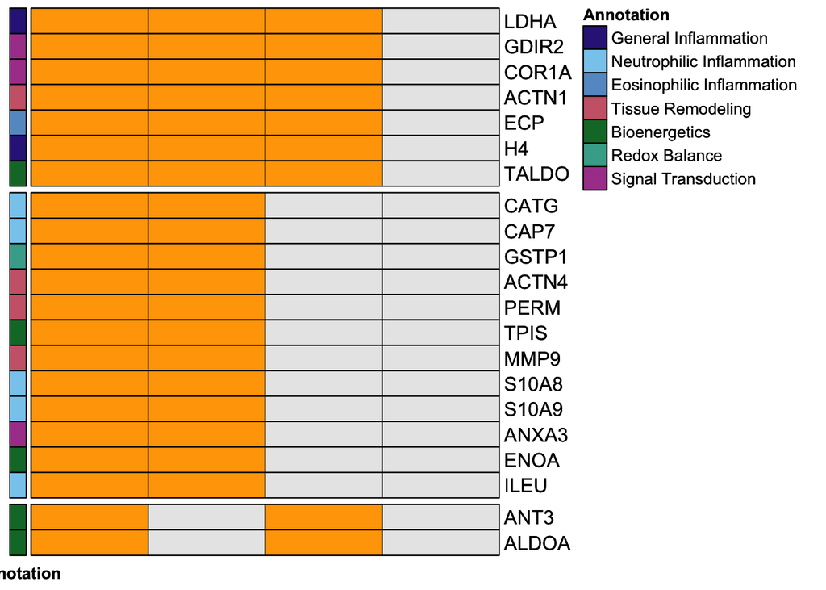

```r
# Read in annotation data frame
anno <- read.xlsx("1_InputData/ECig_Asthma_Overlap_Proteins_Annotation.xlsx") %>%
  column_to_rownames("protein") %>%
  mutate(Annotation = as.factor(Annotation))

# Define annontation colors
hm_colors <- list(
  Annotation = c(`General Inflammation` = "#332288",
                 `Neutrophilic Inflammation` = "#88CCEE",
                 `Eosinophilic Inflammation` ="#6699CC",
                 `Tissue Remodeling` = "#CC6677",
                 `Bioenergetics` = "#117733",
                 `Redox Balance` = "#44AA99",
                 `Signal Transduction` = "#AA4499"))

# Make heatmap
heatmap_subset_anno <- pheatmap(hm_data_subset %>% select(-c(cluster, index)),
         cluster_rows = FALSE,
         cluster_cols = FALSE,
         show_rownames = TRUE,
         show_colnames = FALSE,
         legend = FALSE,
         color = c("gray91","orange1"),
         fontsize_row = 12,
         angle_col = 0,
         gaps_row = seprows,
         border_color = "black",
         annotation_row = anno,
         annotation_colors = hm_colors)

heatmap_subset_anno
```

```r
ggsave(heatmap_subset_anno, file = "2_OutputFigs/Ecig_Asthma_Overlap_Heatmap_Subset_Anno.png", width = 7, height = 5)
```

Jaccard distance for zoomed in plot:

```r
# Transpose dataframe and convert to matrix
protein_countmatrix_subset_T <- as.data.frame(t(protein_countmatrix_subset %>% select(-cluster)))

# Calculate Jaccard *distance* for groups
group_jaccard_dist_subset <- vegdist(protein_countmatrix_subset_T , method="jaccard", na.rm = TRUE)
group_jaccard_dist_subset <- as.data.frame(as.matrix(group_jaccard_dist_subset))

# Calculate Jaccard *similarity* (JD+JS=1  ->  JS=1-JD) for genes
group_jaccard_sim_subset <- group_jaccard_dist_subset %>% mutate(across(everything(),~1-.x))

# View Jaccard similarity
group_jaccard_sim_subset
```

```
##                  ecig eos_asthma neut_asthma atop_asthma
## ecig        1.0000000  0.4285714   0.9047619           0
## eos_asthma  0.4285714  1.0000000   0.3333333           0
## neut_asthma 0.9047619  0.3333333   1.0000000           0
## atop_asthma 0.0000000  0.0000000   0.0000000           1
```